# DETECCIÓN DE REGIONES GENÓMICAS RESPONSABLES DE LA ADAPTACIÓN LOCAL

Taller congreso SEBOT. Toledo 2021

Jose Luis Blanco Pastor

07 septiembre, 2021

#Options

# Load dataset (available at https://onlinelibrary.wiley.com/doi/full/10.1111/mec.16061)

```r
#Running time ~ 30s

snps_sativa <- read.PLINK(file = "data/Msativa_SNP_data_Blanco_Pastor_2021.raw",
                   map.file="data/Msativa_SNP_data_Blanco_Pastor_2021.map", parallel = F)
```

```
 Reading PLINK raw format into a genlight object...


 Reading loci information...

 Reading and converting genotypes...
.
 Building final object...

...done.
```

```r
snps_sativa_mat <- as.matrix(snps_sativa)
rownames(snps_sativa_mat) <- gsub("^X", "", rownames(snps_sativa_mat))
```

# Data cleaning

```r
#Running time ~5s

#Transform to numeric
snps_sativa_mat <- unfactor(as.data.frame(snps_sativa_mat))

#Leave in populations with <=50% missing data
delete.na <- function(df, n) {
  df[rowSums(is.na(df)) <= n,] #Populations in rows
}

snps_sativa_mat_50md <- delete.na(snps_sativa_mat, n= length(colnames(snps_sativa_mat))*0.5)
```

#Transform individual genotypes to population genotypes

```r
#Running time ~1m

##Allele frequency data

#Specify a matrix of allele frequency data for your samples
snps_sativa_mat_50md_mat <- as.matrix(snps_sativa_mat_50md)

#Pick an allele to count across all samples (remind that it is coded to 0 1 2, being 1 heterozygous genotype)
#Here we pick the alternative allele
#The frequency of the counted allele at a locus in a sample is the number of times the counted allele is observed at a locus divided by the number of **chromosomes** genotyped in that sample

as.data.frame(snps_sativa_mat_50md_mat[1:5,1:5])
```

|  | S1_46623_A | S1_102639_A | S1_102643_C | S1_176202_C | S1_193129_A |
| --- | --- | --- | --- | --- | --- |
| 31jb14_3 | 0 | NA | NA | NA | 1 |
| 31jb14_4 | 0 | 0 | 0 | 0 | 2 |
| 31jb14_5 | 0 | 0 | 0 | 0 | NA |
| 32jb14_3 | 0 | NA | NA | NA | 2 |
| 34jb14_5 | 0 | 0 | 0 | NA | 2 |

```r
snps_sativa_mat_50md_mat[snps_sativa_mat_50md_mat==1] <- 0.5 #Heterozygous
snps_sativa_mat_50md_mat[snps_sativa_mat_50md_mat==0] <- 1 #Alternative allele (we quantify this)
snps_sativa_mat_50md_mat[snps_sativa_mat_50md_mat==2] <- 0 #Reference allele
as.data.frame(snps_sativa_mat_50md_mat[1:5,1:5])
```

|  | S1_46623_A | S1_102639_A | S1_102643_C | S1_176202_C | S1_193129_A |
| --- | --- | --- | --- | --- | --- |
| 31jb14_3 | 1 | NA | NA | NA | 0.5 |
| 31jb14_4 | 1 | 1 | 1 | 1 | 0.0 |
| 31jb14_5 | 1 | 1 | 1 | 1 | NA |
| 32jb14_3 | 1 | NA | NA | NA | 0.0 |
| 34jb14_5 | 1 | 1 | 1 | NA | 0.0 |

```r
#A sample can consist of a single individual or multiple individuals lumped together
#We transform the Msativa dataset from individual sample to population sample
snps_sativa_mat_50md_mat <- as.data.frame(snps_sativa_mat_50md_mat)
snps_sativa_mat_50md_mat$pop <- str_extract(rownames(snps_sativa_mat_50md_mat), ".*(?=_.)") #We extract population codes

#merge individuals into populations
snps_sativa_mat_50md_mat_dt <- as.data.table(snps_sativa_mat_50md_mat)
setkey(snps_sativa_mat_50md_mat_dt, pop) #Show population codes in ascending order
snps_sativa_mat_50md_mat_dt_pop <- snps_sativa_mat_50md_mat_dt[, lapply(.SD,mean, na.rm =T), by=pop] #.SD means (subsets of data.table), in this case defined by "pop".
as.data.frame(snps_sativa_mat_50md_mat_dt_pop[1:5,1:10])
```

| pop | S1_46623_A | S1_102639_A | S1_102643_C | S1_176202_C | S1_193129_A | S1_201085_A | S1_202543_T | S1_202789_T | S1_222241_A |
| --- | --- | --- | --- | --- | --- | --- | --- | --- | --- |
| 31jb14 | 1 | 1 | 1 | 1 | 0.25 | 0.8333333 | 1.00 | 1.00 | NaN |
| 32jb14 | 1 | NaN | NaN | NaN | 0.00 | 1.0000000 | 0.50 | NaN | NaN |
| 34jb14 | 1 | 1 | 1 | NaN | 0.00 | 1.0000000 | 0.50 | 0.50 | NaN |
| 38jb14 | 1 | NaN | NaN | NaN | 0.00 | 1.0000000 | 0.75 | 0.75 | 0.5 |
| 39jb14 | 1 | NaN | NaN | NaN | 0.00 | 1.0000000 | 1.00 | 1.00 | 1.0 |

#Impute missing data

```r
#Running time ~1s

#Data formatting
snps_sativa_mat_50md_mat_dt_pop <- as.data.frame(snps_sativa_mat_50md_mat_dt_pop)
row.names(snps_sativa_mat_50md_mat_dt_pop) <- snps_sativa_mat_50md_mat_dt_pop$pop
snps_sativa_mat_50md_mat_dt_pop$pop <- NULL

snps_sativa_mat_50md_mat_dt_pop_mat <- as.matrix(as.data.frame(snps_sativa_mat_50md_mat_dt_pop))

#Impute missing data with mean values across populations
snps_sativa_mat_50md_mat_dt_pop_mat_imputed <- snps_sativa_mat_50md_mat_dt_pop_mat
for(i in 1:ncol(snps_sativa_mat_50md_mat_dt_pop_mat_imputed)){
  snps_sativa_mat_50md_mat_dt_pop_mat_imputed[is.na(snps_sativa_mat_50md_mat_dt_pop_mat_imputed[,i]), i] <- mean(snps_sativa_mat_50md_mat_dt_pop_mat_imputed[,i], na.rm = TRUE)
}
```

#Genetic structure

```r
#Running time ~20s

#**Model free** clustering procedure used in Discriminant Analysis of Principal Components (DAPC, Jombart et al. 2010).
#k-means, a very popular **Machine Learning clustering algorithm** which finds a given number of K groups maximizing the variation between groups.

fc <- find.clusters(snps_sativa_mat_50md_mat_dt_pop_mat_imputed, n.pca= 99, n.clust = NULL, choose.n.clust= FALSE, criterion= "diffNgroup", n.iter= 1E4, n.start= 100, center=TRUE, scale=FALSE) #  If n.clust left as NULL, several K-means are run for a range of k (number of clusters) values.
```

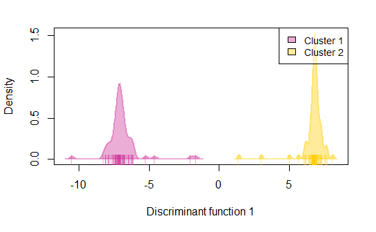

```r
#Running time ~10s

#DAPC function (Discriminant Analysis of Principal Components), first transforms the data using PCA, and then performs a Discriminant Analysis on the Retained principal components, using clusters as the discriminating variable. Based on the retained discriminant functions it allows to compute allele contributions to genetic clusters and therefore provides membership probabilities of each population for the diferent K groups.

dapc1 <- dapc(snps_sativa_mat_50md_mat_dt_pop_mat_imputed, fc$grp, n.pca = 99, n.da=4)

mycol <- c("#CC3399", "#FFCC00")

scatter(dapc1, scree.da=TRUE, bg="white", pch=20, cell=0, cstar=0, col=mycol, solid=.4,
        cex=1.5,clab=0, leg=TRUE, txt.leg=paste("Cluster",1:2),posi.da="bottomright",  ratio.da = 0.18, cleg = 0.9)
```

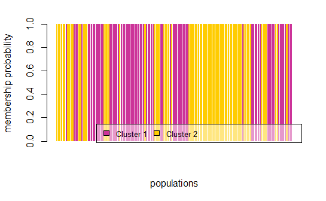

```r
#Individual's membership to clusters
compoplot(dapc1, posi="bottomright",
          txt.leg=paste("Cluster", 1:2), lab="",
          ncol=1, xlab="populations", col=mycol)
```

##Geographic sampling coordinates

```r
#Running time ~1s

Msativa_coordinates <-read.csv2("data/Medicago_sativa_samples.csv", header =T, as.is=T, dec=",", sep=";", check.names = T)
Msativa_coordinates$accessionN_SampleN <- str_extract(Msativa_coordinates$accessionN_SampleN, ".*(?=_.)")

Msativa_coordinates <- Msativa_coordinates[Msativa_coordinates$accessionN_SampleN %in% rownames(snps_sativa_mat_50md_mat_dt_pop),3:4]
```

## Pie plot on a map

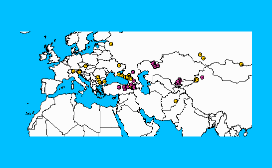

```r
#Running time ~5s

# make the desired map
    maps::map(xlim = range(Msativa_coordinates[,1]) + c(-30,5), ylim = range(Msativa_coordinates[,2])+c(-15,5), col="gray99", fill = T, bg = "deepskyblue1")

# add the pie plot
    make.admix.pie.plot(admix.proportions = dapc1$posterior,
                        coords = Msativa_coordinates,
                        add = T,
                        radii = 1,
                        layer.colors = mycol)
```

```r
NA
NA
```

Yellow: M. sativa ssp. falcata (cold adapted) Purple: M. sativa ssp. caerulea (drought adapted)

(Careful as “fc” function assigns order of clusters arbitrarily and color indexes may change)

# RDA

## Raster data

```r
#Data below takes around 30 min to download. We will load a .rds file instead.

#Running time ~30s

# raster_data <- list.files(path = "E:/Work data/Analyses/2016/2016_01_15_AlfalfaLandscapeGenetics/R/data/crop", pattern="\\.grd$", full.names=TRUE) #36GB in raster data
#
# # Create a collection of layers with 'STACK'
# stack_raster <- stack(raster_data)
#
# #Extract information from populations GPS positions
# loc <- Msativa_coordinates[,c("lon", "lat")]
# ext <- raster::extract(stack_raster, loc)
# Msativa_env_data <- cbind(Msativa_coordinates, ext)

# saveRDS(Msativa_env_data, file = "data/Msativa_env_data.rds")
Msativa_env_data <- readRDS("data/Msativa_env_data.rds")
```

RDA requires complete data frames (i.e., no missing data). We imputed missing values using the mean value at each environmental variable across all individuals.

```r
#Running time ~5s

Msativa_env_data_imputed <- Msativa_env_data
rownames(Msativa_env_data_imputed) <- Msativa_env_data_imputed$accessionN_SampleN

Msativa_env_data_imputed  <- Msativa_env_data_imputed[,3:57]

#Impute missing data with mean values across populations
for(i in 1:ncol(Msativa_env_data_imputed)){
  Msativa_env_data_imputed[is.na(Msativa_env_data_imputed[,i]), i] <- mean(Msativa_env_data_imputed[,i], na.rm = TRUE)
}
```

##Environmental variables check ###Correlation matrix

```r
#Running time ~10s

pdf("data/pairs_panels.pdf",width=32,height=32, paper='special')
pairs.panels(Msativa_env_data_imputed, scale=T, method="spearman")
dev.off()
```

###VIF

image:

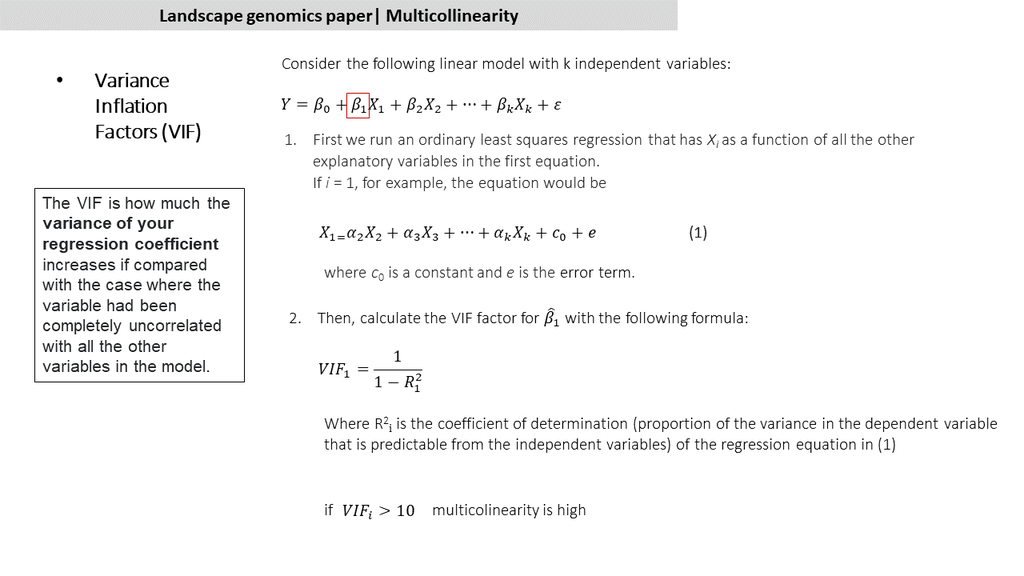

```r
#Running time ~10s

#The RDA analysis with **ALL VARIABLES** and VIF calculation

# Msativa
rda_bioclim_Msat<-rda(snps_sativa_mat_50md_mat_dt_pop_mat_imputed, Msativa_env_data_imputed, scale=T)

rda_bioclim_Msat
```

```
Call: rda(X =
snps_sativa_mat_50md_mat_dt_pop_mat_imputed, Y =
Msativa_env_data_imputed, scale = T)

                 Inertia Proportion Rank
Total         14160.0000     1.0000
Constrained    7774.7895     0.5491   54
Unconstrained  6385.2105     0.4509   95
Inertia is correlations
Some constraints were aliased because they were collinear (redundant)

Eigenvalues for constrained axes:
  RDA1   RDA2   RDA3   RDA4   RDA5   RDA6   RDA7   RDA8   RDA9
2699.4  939.7  317.4  208.3  186.9  158.5  140.6  136.2  112.4
 RDA10  RDA11  RDA12  RDA13  RDA14  RDA15  RDA16  RDA17  RDA18
 108.4  104.8   98.6   94.5   91.6   88.7   86.7   81.9   80.0
 RDA19  RDA20  RDA21  RDA22  RDA23  RDA24  RDA25  RDA26  RDA27
  77.8   76.7   74.7   73.4   72.6   71.6   69.9   67.5   66.3
 RDA28  RDA29  RDA30  RDA31  RDA32  RDA33  RDA34  RDA35  RDA36
  65.2   64.3   63.5   62.0   61.7   59.7   58.1   57.8   56.8
 RDA37  RDA38  RDA39  RDA40  RDA41  RDA42  RDA43  RDA44  RDA45
  56.0   54.2   53.9   52.7   52.2   50.3   50.0   49.5   47.4
 RDA46  RDA47  RDA48  RDA49  RDA50  RDA51  RDA52  RDA53  RDA54
  46.6   45.2   43.7   43.5   41.8   40.8   39.3   38.4   35.2

Eigenvalues for unconstrained axes:
   PC1    PC2    PC3    PC4    PC5    PC6    PC7    PC8
240.50 140.56 133.05 104.60 102.33 100.59  99.45  96.97
(Showing 8 of 95 unconstrained eigenvalues)
```

```r
print("VIF")
```

```
[1] "VIF"
```

```r
vif.cca(rda_bioclim_Msat)
```

```
        CMSAF_SDL      CMSAF_SISCLS           CRU_CLD
        47.161496        194.224515        201.176032
          CRU_FRS           CRU_PET           CRU_PRE
        77.319124        238.059447         66.723039
          CRU_VAP           CRU_WET    DAAC_AWC_CLASS
        63.673709         57.954688         31.652848
   DAAC_AWT_S_SOC    DAAC_AWT_T_SOC           DAAC_BD
        50.919913         45.344250      58115.709845
       DAAC_DUNNE           DAAC_FC         DAAC_PAWC
         9.974635 6066881422.866359 2319123221.249911
   DAAC_REF_DEPTH   DAAC_S_CEC_CLAY       DAAC_S_CLAY
       645.870870        107.478013        262.095635
    DAAC_S_GRAVEL         DAAC_S_OC     DAAC_S_PH_H2O
         9.998783       4543.191057       2298.784216
      DAAC_S_SAND       DAAC_S_SILT         DAAC_SMBC
       267.413446        351.955459         33.096601
        DAAC_SMBN          DAAC_SPD   DAAC_T_CEC_CLAY
        71.794261          4.853330         37.358952
      DAAC_T_CLAY     DAAC_T_GRAVEL         DAAC_T_OC
        93.519914         98.369734       5072.790368
    DAAC_T_PH_H2O       DAAC_T_SAND       DAAC_T_SILT
       357.982062        169.354480        112.415541
          DAAC_TC          DAAC_TND           DAAC_WP
     58113.298205         10.822746 1065133199.779469
          WC_BIO1          WC_BIO10          WC_BIO11
      2890.535017       6974.023317      41513.362534
         WC_BIO12          WC_BIO13          WC_BIO14
       651.359781        404.122302        758.060624
         WC_BIO15          WC_BIO16          WC_BIO17
       162.303526        945.505585        985.613611
         WC_BIO18          WC_BIO19           WC_BIO2
       411.204827        143.236805       1966.546798
          WC_BIO3           WC_BIO4           WC_BIO5
       755.828109      35906.366072       2624.238443
          WC_BIO6           WC_BIO7           WC_BIO8
     12261.755260                NA          9.253091
          WC_BIO9
        16.204837
```

Problems with VIF: -Almost all variables with VIF>10 when many variables are considered -Discourages synthetic variables (variable resumen)

###Proposed variable reduction strategy

```r
#Running time ~2s

# Our protocol for variable reduction proceeded as follows:
# First, we performed cluster analyses of factors according to a matrix of absolute correlation values |r|.

#Cluster analysis 1
vcor <- cor(Msativa_env_data_imputed)
vdist<-abs(as.dist(vcor))
vcluster<-hclust(1-vdist, method = "complete")
par(cex=0.8)
plot(vcluster, main = "Msativa")
abline(h=0.3, col="red")
```

[figure not shown]

```r
Msativa_env_data_imputed2 <- Msativa_env_data_imputed[,c("CRU_FRS", "CRU_PET", "CRU_PRE", "CRU_VAP", "DAAC_AWC_CLASS", "DAAC_BD", "DAAC_DUNNE", "DAAC_FC", "DAAC_S_GRAVEL", "DAAC_S_OC", "DAAC_S_PH_H2O", "DAAC_S_SAND", "DAAC_SMBC", "DAAC_SPD", "DAAC_T_CEC_CLAY", "DAAC_T_CLAY", "DAAC_T_GRAVEL", "DAAC_T_PH_H2O", "DAAC_T_SILT", "DAAC_TND", "WC_BIO10","WC_BIO12", "WC_BIO14", "WC_BIO3", "WC_BIO4", "WC_BIO5", "WC_BIO6", "WC_BIO8", "WC_BIO9")]

#Cluster analysis 2
vcor <- cor(Msativa_env_data_imputed2)
vdist<-abs(as.dist(vcor))
vcluster<-hclust(1-vdist, method = "complete")
par(cex=0.8)
```

```r
plot(vcluster, main = "Msativa")
abline(h=0.3, col="red")
```

[figure not shown]

```r
 Msativa_env_data_imputed3 <- Msativa_env_data_imputed2[,c("CRU_PET", "CRU_PRE", "DAAC_AWC_CLASS", "DAAC_BD", "DAAC_DUNNE", "DAAC_FC", "DAAC_S_GRAVEL", "DAAC_S_PH_H2O", "DAAC_SMBC", "DAAC_SPD", "DAAC_T_CEC_CLAY", "DAAC_T_CLAY" , "DAAC_T_PH_H2O", "DAAC_T_SILT", "DAAC_TND", "WC_BIO14", "WC_BIO3", "WC_BIO5", "WC_BIO6", "WC_BIO8")]

#Cluster analysis 3
vcor <- cor(Msativa_env_data_imputed3)
vdist<-abs(as.dist(vcor))
vcluster<-hclust(1-vdist, method = "complete")
par(cex=0.8)
```

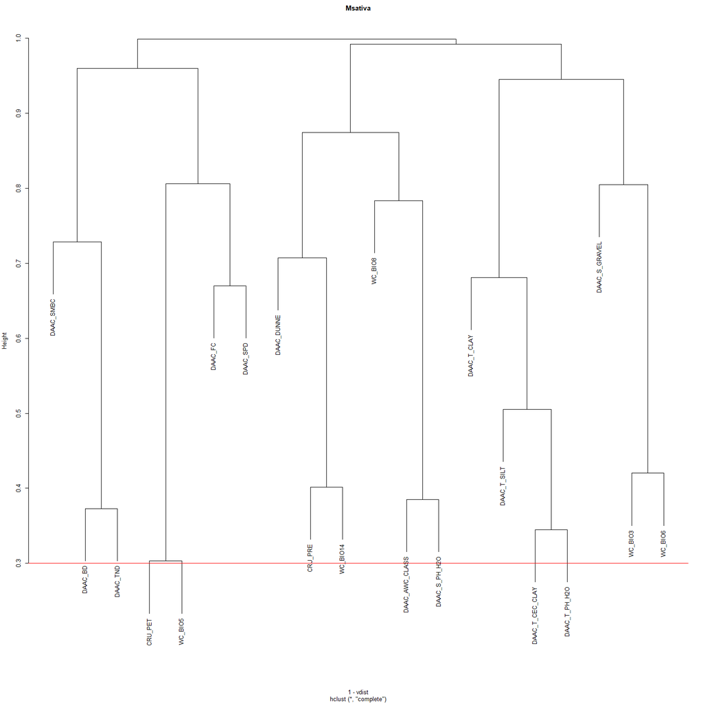

```r
plot(vcluster, main = "Msativa")
abline(h=0.3, col="red")
```

After subsequent cluster analyses, we retained one variable in clusters with distance among variables lower than 0.3 (correlation higher than 0.7). We favoured temperature variables over precipitation or radiation variables, monthly over quarterly climatic variables and topsoil over subsoil variables. After a preliminary RDA analysis, we also checked for multicollinearity using variance inflation factors (VIF) and confirmed that VIF of selected variables was <10.

##RDA bioclim

```r
#Running time ~5s

#The RDA analysis (bioclimatic data)

# Msativa
rda_bioclim_Msat<-rda(snps_sativa_mat_50md_mat_dt_pop_mat_imputed ~ CRU_PET + CRU_PRE +  WC_BIO14 + WC_BIO3 + WC_BIO5 + WC_BIO6 + WC_BIO8,
         Msativa_env_data_imputed3, scale=T)

rda_bioclim_Msat
```

```
Call: rda(formula =
snps_sativa_mat_50md_mat_dt_pop_mat_imputed ~ CRU_PET +
CRU_PRE + WC_BIO14 + WC_BIO3 + WC_BIO5 + WC_BIO6 +
WC_BIO8, data = Msativa_env_data_imputed3, scale = T)

                 Inertia Proportion Rank
Total         14160.0000     1.0000
Constrained    3071.8620     0.2169    7
Unconstrained 11088.1380     0.7831  142
Inertia is correlations

Eigenvalues for constrained axes:
  RDA1   RDA2   RDA3   RDA4   RDA5   RDA6   RDA7
2066.8  406.4  182.7  140.4  121.2   85.9   68.5

Eigenvalues for unconstrained axes:
  PC1   PC2   PC3   PC4   PC5   PC6   PC7   PC8
943.3 699.0 256.9 186.8 164.5 160.0 130.8 120.5
(Showing 8 of 142 unconstrained eigenvalues)
```

```r
print("VIF")
```

```
[1] "VIF"
```

```r
vif.cca(rda_bioclim_Msat)
```

```
 CRU_PET  CRU_PRE WC_BIO14  WC_BIO3  WC_BIO5  WC_BIO6  WC_BIO8
4.146212 2.679686 3.112982 2.604254 2.495243 2.891008 1.342179
```

##The RDA plot Axes are composite variables that represent genetic data constrained by their association with environmental data.

```r
#Running time ~5s

admix.props_Msat_plot <- dapc1$posterior
colnames(admix.props_Msat_plot) <- c("caerulea", "falcata")
admix.props_Msat_plot <- as.data.frame(admix.props_Msat_plot)
admix.props_Msat_plot$cluster_membership <- colnames(admix.props_Msat_plot)[apply(admix.props_Msat_plot,1,which.max)]

colorby <- admix.props_Msat_plot$cluster_membership
colorby <- as.factor(colorby)

bg <- c("#CC3399", "#FFCC00") # colors of our clusters **according to the order of levels**

sel <- rownames(rda_bioclim_Msat$CCA$biplot)

# axes 1 & 2
plot(rda_bioclim_Msat, type="n")
points(rda_bioclim_Msat, display="species", pch=20, cex=0.7, col="gray32", scaling=3)               # the snps
```

```r
points(rda_bioclim_Msat, display="sites", pch=21, cex=1.5, col="gray32", scaling=3, bg=bg[colorby]) # the populations
text(rda_bioclim_Msat, display = "bp", col="#0868ac", cex=1)                         # the predictors
```

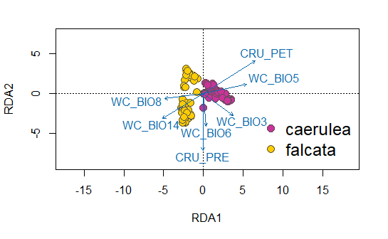

```r
legend("bottomright", legend = levels(colorby), bty = "n", col="gray32", pch = 21, cex=1.5, pt.bg = bg)
```

```r
#SNPs only
# axes 1 & 2
plot(rda_bioclim_Msat, type="n", xlim=c(-1,1), ylim=c(-1,1),)
points(rda_bioclim_Msat, display="species", pch=20, cex=0.7, col="gray32", scaling=3)               # the snps
```

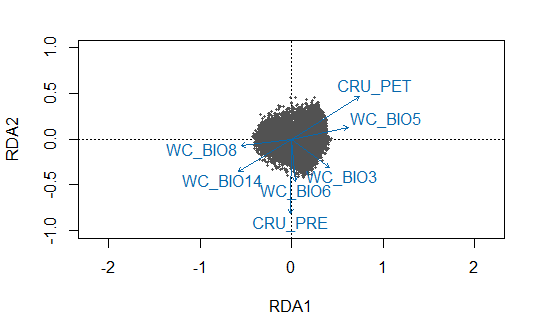

```r
text(rda_bioclim_Msat, display = "bp", col="#0868ac", cex=1)                         # the predictors
```

```r
NA
NA
```

BIO5 = Max Temperature of Warmest Month BIO8 = Mean Temperature of Wettest Quarter

Remember that axis represent a linear combination of genotipic variables constrained by environmental data.

Fig1 - Here we observe the populations as defined by their genetic variation associated with environmental data.

Fig2 - Here we observe the SNPs as defined by their relationship with environmental data

This reflects a genome-wide pattern of isolation-by-environment (IBE) where clusters represent genetic groups with different niche breadth. **Finding outliers can be difficult under this patern**

## RDA: Identify candidate SNPs involved in local adaptation

```r
#Running time ~1s

# The function returning p-values and q-values for all the loci

rdadapt<-function(rda,K)
{
  loadings<-rda$CCA$v[,1:as.numeric(K)]
  resscale <- apply(loadings, 2, scale)
  resmaha <- covRob(resscale, distance = TRUE, na.action= na.omit, estim="pairwiseGK")$dist
  lambda <- median(resmaha)/qchisq(0.5,df=K)
  reschi2test <- pchisq(resmaha/lambda,K,lower.tail=FALSE)
  qval <- qvalue(reschi2test)
  q.values_rdadapt<-qval$qvalues
  loci_names <- dimnames(rda$CCA$v)[[1]]
  return(data.frame(loci=loci_names, mahalanobisD = resmaha, p.values=reschi2test, q.values=q.values_rdadapt, stringsAsFactors = F))
}

# Using rdadapt function with K=7 (7 variables)
K <- 7
res_rdadapt_bioclim_Msat<-rdadapt(rda_bioclim_Msat, K)
```

##Manhattan plots

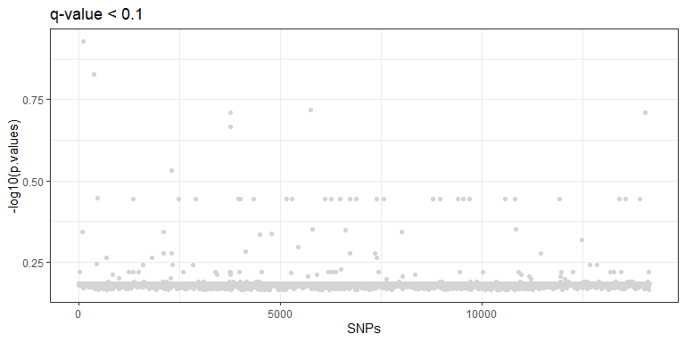

```r
#Running time ~1s

# qvalue < 0.1
p1<- ggplot() +
  geom_point(aes(x=c(1:length(res_rdadapt_bioclim_Msat[,4])), y=-log10(res_rdadapt_bioclim_Msat[,4])), col = "gray83") +
  geom_point(aes(x=c(1:length(res_rdadapt_bioclim_Msat[,4]))[which(res_rdadapt_bioclim_Msat[,4] < 0.1)], y=-log10(res_rdadapt_bioclim_Msat[which(res_rdadapt_bioclim_Msat[,4] < 0.1),4])), col = "indianred3") +
  xlab("SNPs") + ylab("-log10(p.values)") +
  ggtitle("q-value < 0.1") +
  theme_bw()
p1
```

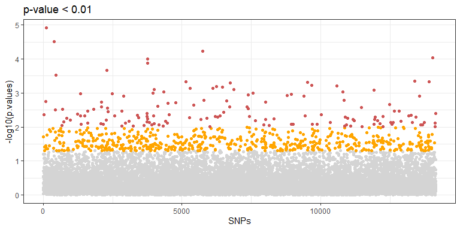

```r
#Running time ~1s

# p-value < 0.01
p2<- ggplot() +
  geom_point(aes(x=c(1:length(res_rdadapt_bioclim_Msat[,3])), y=-log10(res_rdadapt_bioclim_Msat[,3])), col = "gray83") +
  geom_point(aes(x=c(1:length(res_rdadapt_bioclim_Msat[,3]))[which(res_rdadapt_bioclim_Msat[,3] < 0.05)], y=-log10(res_rdadapt_bioclim_Msat[which(res_rdadapt_bioclim_Msat[,3] < 0.05),3])), col = "orange") +
  geom_point(aes(x=c(1:length(res_rdadapt_bioclim_Msat[,3]))[which(res_rdadapt_bioclim_Msat[,3] < 0.01)], y=-log10(res_rdadapt_bioclim_Msat[which(res_rdadapt_bioclim_Msat[,3] < 0.01),3])), col = "indianred3") +
  xlab("SNPs") + ylab("-log10(p.values)") +
  ggtitle("p-value < 0.01") +
  theme_bw()
p2
```

```r
#Running time ~1s

# Outliers loci (p-value < 0.01)
length(which(res_rdadapt_bioclim_Msat[,3] < 0.01))
```

```
[1] 143
```

#LFMM analyses LFMMs are defined according to the following formula
$$Y = X B^T + U V^T + E$$
where $Y$ is the matrix of SNPs on individuals, $X$ is the matrix of explanatory (here environmental) variables , $B$ is a matrix of effects for all explanatory variables, $U$ is a matrix of latent variables (i.e. population structure), and $V$ is a matrix of loadings for K latent variables.

This formula that uses matrices can be decomposed in uniresponse (SNP by SNP) multivariate linear regressions:
$$y_{l} = x\beta_{l} + Ûv^T_{l} + e_{l}$$
where $y_{l}$ is the SNP locus, $x$ is the environmental variable, $\beta_{l}$ is the effect of the environmental variable, $Û$ is a matrix defined by K latent variables (i.e. clusters) and v_{l} are their corresponding effect sizes.

This is a typical mixed model used in GEA methods (below the notation used in GWAS by Yu et al. 2006):

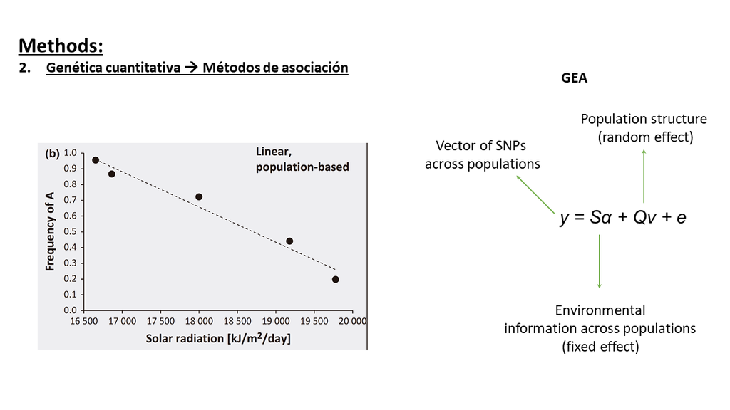

```r
#Running time ~1s

##scale environmental data [-1,1] (mean of 0 and sd of 1)
Msativa_env_data_imputed3_scale <- scale(Msativa_env_data_imputed3)
# check scale
colMeans(Msativa_env_data_imputed3_scale, na.rm = T)  # faster version of apply(scaled.dat, 2, mean)
```

```
                     CRU_PET                      CRU_PRE
-0.0000000000000000273392420  0.0000000000000000095756736
              DAAC_AWC_CLASS                      DAAC_BD
-0.0000000000000000546553543  0.0000000000000003250640498
                  DAAC_DUNNE                      DAAC_FC
-0.0000000000000000007632783 -0.0000000000000000654800288
               DAAC_S_GRAVEL                DAAC_S_PH_H2O
-0.0000000000000000099630952  0.0000000000000001351696532
                   DAAC_SMBC                     DAAC_SPD
-0.0000000000000001516379614  0.0000000000000001550322370
             DAAC_T_CEC_CLAY                  DAAC_T_CLAY
 0.0000000000000001773118689  0.0000000000000000196833290
               DAAC_T_PH_H2O                  DAAC_T_SILT
 0.0000000000000002265086267 -0.0000000000000001200949062
                    DAAC_TND                     WC_BIO14
-0.0000000000000002146199884  0.0000000000000000215568304
                     WC_BIO3                      WC_BIO5
 0.0000000000000003693602137  0.0000000000000005352315813
                     WC_BIO6                      WC_BIO8
-0.0000000000000000450102918  0.0000000000000000276514922
```

```r
apply(Msativa_env_data_imputed3_scale, 2, sd, na.rm = T)
```

```
        CRU_PET         CRU_PRE  DAAC_AWC_CLASS         DAAC_BD
              1               1               1               1
     DAAC_DUNNE         DAAC_FC   DAAC_S_GRAVEL   DAAC_S_PH_H2O
              1               1               1               1
      DAAC_SMBC        DAAC_SPD DAAC_T_CEC_CLAY     DAAC_T_CLAY
              1               1               1               1
  DAAC_T_PH_H2O     DAAC_T_SILT        DAAC_TND        WC_BIO14
              1               1               1               1
        WC_BIO3         WC_BIO5         WC_BIO6         WC_BIO8
              1               1               1               1
```

RDA is based on multivariate linear regressions LFMM is based on univariate linear regressions. Environment is multidimensional. We solve this in LFMM by modelling SNPs using Principal Components of environmental data as bioclimatic descriptors.

## LFMM with principal components of environmental variables

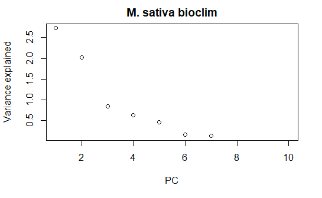

```r
##Principal component analysis of environmental data
#Running time ~1s

pc_sativa_bioclim <- prcomp(Msativa_env_data_imputed3_scale[, c("CRU_PET", "CRU_PRE", "WC_BIO14", "WC_BIO3", "WC_BIO5", "WC_BIO6", "WC_BIO8")])
plot(pc_sativa_bioclim$sdev[1:10]^2, xlab = 'PC', ylab = "Variance explained", main = "M. sativa bioclim")
```

LFMM formula
$$Y = X B^T + U V^T + E$$

```r
#Running time ~1s

##lfmm
# bioclim (principal components)
##penalized least squares regression (ridge penalty)

mod.lfmm_bioclim_pca_Msat <- lfmm_ridge(Y = snps_sativa_mat_50md_mat_dt_pop_mat_imputed,
                        X = pc_sativa_bioclim$x[,1:3],
                        K = 2)
```

```r
#Running time ~5s

## performs association testing using the fitted model (p-values):

pv_bioclim_pca_Msat <- lfmm_test(Y = snps_sativa_mat_50md_mat_dt_pop_mat_imputed,
                        X = pc_sativa_bioclim$x[,1:3],
                 lfmm = mod.lfmm_bioclim_pca_Msat,
                 calibrate = "gif")

colnames(pv_bioclim_pca_Msat$calibrated.pvalue) <- c("PC1.bioclim", "PC2.bioclim", "PC3.bioclim")
```

$$y_{l} = x\beta_{l} + Ûv^T_{l} + e_{l}$$
Scaled regression coefficients of environmental effects ($\beta_{l}$) follow a normal distribution and have associated Zscores.

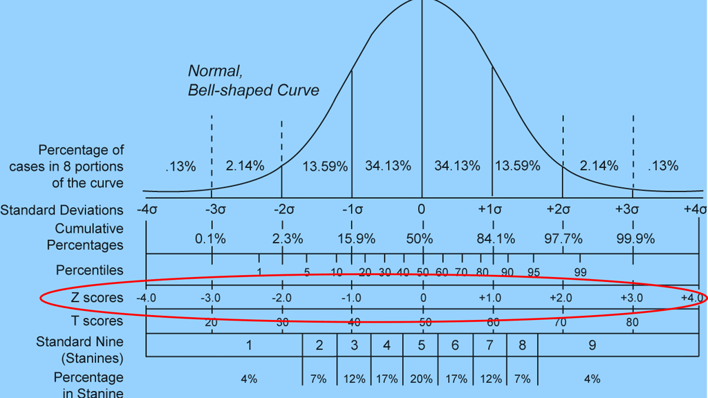

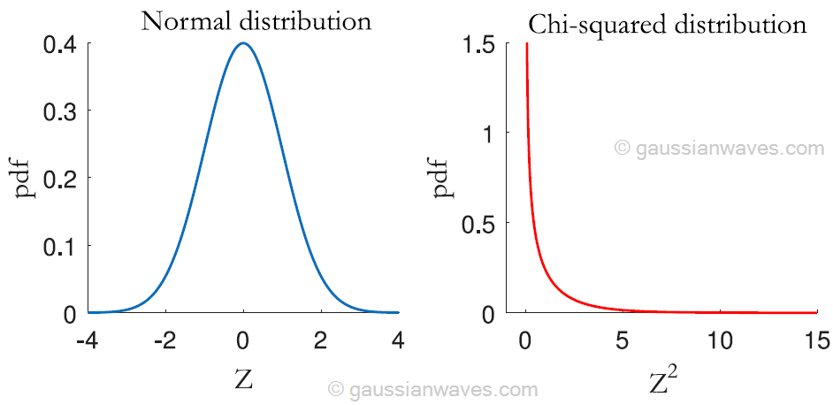

$z^2-scores$ follows a chi-squared distribution from which p-values are calculated.

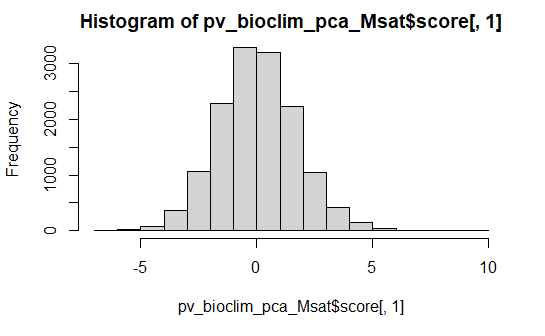

```r
# chi-squared transformation
hist(pv_bioclim_pca_Msat$score[,1])
```

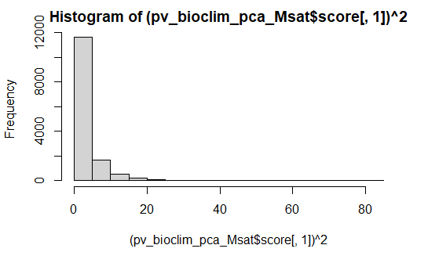

```r
hist((pv_bioclim_pca_Msat$score[,1])^2)
```

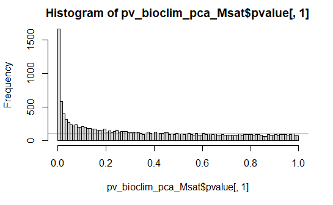

```r
hist(pv_bioclim_pca_Msat$pvalue[,1], breaks = 99)
abline(100,0, col= "red")
```

Idealmente la distribución de p-valores debe reflejar p-valores nulos (distribución uniforme) y un enriquecimiento en p-valores no nulos (con valores próximos a 0).

To calibrate p-values we use a **genomic inflation factor**, $\lambda$, defined by Devlin & Roeder (1999) as
$$\lambda = median(z^2/0.456)$$
, where $z^2$ is a vector that contains the test statistic **($z^2-scores$)** for all loci, and 0.456 corresponds to **the median of the chisquare distribution ($Z^2$)**. P-values are correctly calibrated when the inflation factor is close to one (p-values match a chi-squared distribution)

To calibrate p-values that deviate from a chi-squared distribution we modify the $z^2-scores$ by dividing them by $\lambda$.

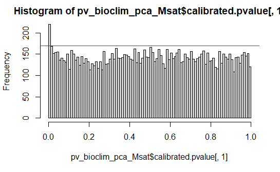

```r
#Effect of aplying the genomic inflation factor (gif)
hist(pv_bioclim_pca_Msat$calibrated.pvalue[,1], breaks = 99)
abline(170,0, col= "red")
```

##Manhattan plot

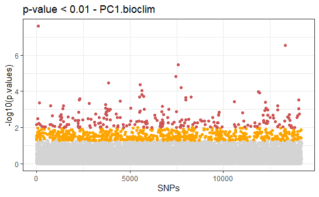

```r
#Running time ~5s

cpvalues_bioclim_pca_Msat <- pv_bioclim_pca_Msat$calibrated.pvalue
qvalues_bioclim_pca_Msat <- qvalue(pv_bioclim_pca_Msat$calibrated.pvalue)

 ## Manhattan plot
#First principal component
ggplot() +
  geom_point(aes(x=c(1:length(cpvalues_bioclim_pca_Msat[,colnames(cpvalues_bioclim_pca_Msat)[1]])), y=-log10(cpvalues_bioclim_pca_Msat[,colnames(cpvalues_bioclim_pca_Msat)[1]])), col = "gray83") +
  geom_point(aes(x=c(1:length(cpvalues_bioclim_pca_Msat[,colnames(cpvalues_bioclim_pca_Msat)[1]]))[which(cpvalues_bioclim_pca_Msat[,colnames(cpvalues_bioclim_pca_Msat)[1]] < 0.05)], y=-log10(cpvalues_bioclim_pca_Msat[which(cpvalues_bioclim_pca_Msat[,colnames(cpvalues_bioclim_pca_Msat)[1]] < 0.05),1])), col = "orange") +
   geom_point(aes(x=c(1:length(cpvalues_bioclim_pca_Msat[,colnames(cpvalues_bioclim_pca_Msat)[1]]))[which(cpvalues_bioclim_pca_Msat[,colnames(cpvalues_bioclim_pca_Msat)[1]] < 0.01)], y=-log10(cpvalues_bioclim_pca_Msat[which(cpvalues_bioclim_pca_Msat[,colnames(cpvalues_bioclim_pca_Msat)[1]] < 0.01),1])), col = "indianred3") +

  xlab("SNPs") + ylab("-log10(p.values)") +
  ggtitle(paste0("p-value < 0.01 - ", colnames(cpvalues_bioclim_pca_Msat)[1])) +
  theme_bw()
```

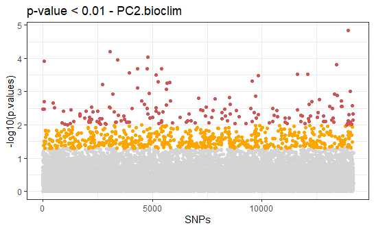

```r
#Second principal component
ggplot() +
  geom_point(aes(x=c(1:length(cpvalues_bioclim_pca_Msat[,colnames(cpvalues_bioclim_pca_Msat)[2]])), y=-log10(cpvalues_bioclim_pca_Msat[,colnames(cpvalues_bioclim_pca_Msat)[2]])), col = "gray83") +
  geom_point(aes(x=c(1:length(cpvalues_bioclim_pca_Msat[,colnames(cpvalues_bioclim_pca_Msat)[2]]))[which(cpvalues_bioclim_pca_Msat[,colnames(cpvalues_bioclim_pca_Msat)[2]] < 0.05)], y=-log10(cpvalues_bioclim_pca_Msat[which(cpvalues_bioclim_pca_Msat[,colnames(cpvalues_bioclim_pca_Msat)[2]] < 0.05),2])), col = "orange") +
   geom_point(aes(x=c(1:length(cpvalues_bioclim_pca_Msat[,colnames(cpvalues_bioclim_pca_Msat)[2]]))[which(cpvalues_bioclim_pca_Msat[,colnames(cpvalues_bioclim_pca_Msat)[2]] < 0.01)], y=-log10(cpvalues_bioclim_pca_Msat[which(cpvalues_bioclim_pca_Msat[,colnames(cpvalues_bioclim_pca_Msat)[2]] < 0.01),2])), col = "indianred3") +

  xlab("SNPs") + ylab("-log10(p.values)") +
  ggtitle(paste0("p-value < 0.01 - ", colnames(cpvalues_bioclim_pca_Msat)[2])) +
  theme_bw()
```

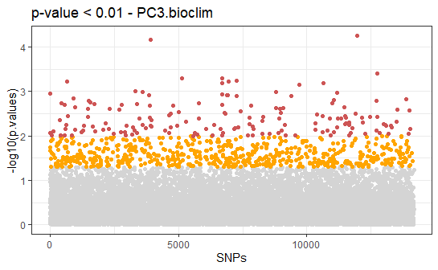

```r
#Third principal component
ggplot() +
  geom_point(aes(x=c(1:length(cpvalues_bioclim_pca_Msat[,colnames(cpvalues_bioclim_pca_Msat)[3]])), y=-log10(cpvalues_bioclim_pca_Msat[,colnames(cpvalues_bioclim_pca_Msat)[3]])), col = "gray83") +
  geom_point(aes(x=c(1:length(cpvalues_bioclim_pca_Msat[,colnames(cpvalues_bioclim_pca_Msat)[3]]))[which(cpvalues_bioclim_pca_Msat[,colnames(cpvalues_bioclim_pca_Msat)[3]] < 0.05)], y=-log10(cpvalues_bioclim_pca_Msat[which(cpvalues_bioclim_pca_Msat[,colnames(cpvalues_bioclim_pca_Msat)[3]] < 0.05),3])), col = "orange") +
   geom_point(aes(x=c(1:length(cpvalues_bioclim_pca_Msat[,colnames(cpvalues_bioclim_pca_Msat)[3]]))[which(cpvalues_bioclim_pca_Msat[,colnames(cpvalues_bioclim_pca_Msat)[3]] < 0.01)], y=-log10(cpvalues_bioclim_pca_Msat[which(cpvalues_bioclim_pca_Msat[,colnames(cpvalues_bioclim_pca_Msat)[3]] < 0.01),3])), col = "indianred3") +

  xlab("SNPs") + ylab("-log10(p.values)") +
  ggtitle(paste0("p-value < 0.01 - ", colnames(cpvalues_bioclim_pca_Msat)[3])) +
  theme_bw()
```

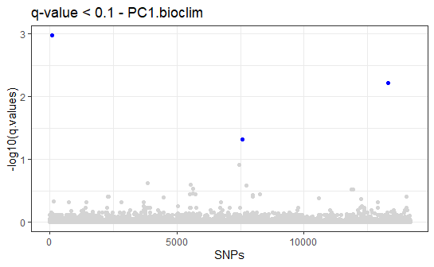

```r
#First principal component
ggplot() +
  geom_point(aes(x=c(1:length(qvalues_bioclim_pca_Msat$qvalues[,colnames(qvalues_bioclim_pca_Msat$qvalues)[1]])), y=-log10(qvalues_bioclim_pca_Msat$qvalues[,colnames(qvalues_bioclim_pca_Msat$qvalues)[1]])), col = "gray83") +

   geom_point(aes(x=c(1:length(qvalues_bioclim_pca_Msat$qvalues[,colnames(qvalues_bioclim_pca_Msat$qvalues)[1]]))[which(qvalues_bioclim_pca_Msat$qvalues[,colnames(qvalues_bioclim_pca_Msat$qvalues)[1]] < 0.1)], y=-log10(qvalues_bioclim_pca_Msat$qvalues[which(qvalues_bioclim_pca_Msat$qvalues[,colnames(qvalues_bioclim_pca_Msat$qvalues)[1]] < 0.1),1])), col = "blue") +

  xlab("SNPs") + ylab("-log10(q.values)") +
  ggtitle(paste0("q-value < 0.1 - ", colnames(cpvalues_bioclim_pca_Msat)[1])) +
  theme_bw()
```

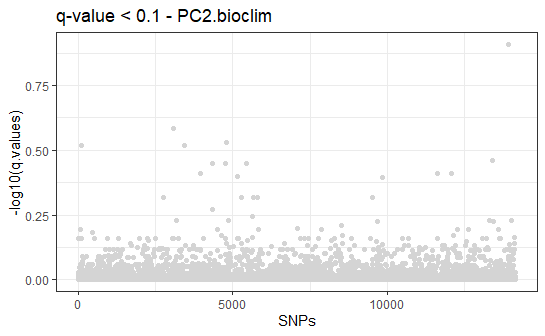

```r
#Second principal component
ggplot() +
  geom_point(aes(x=c(1:length(qvalues_bioclim_pca_Msat$qvalues[,colnames(qvalues_bioclim_pca_Msat$qvalues)[2]])), y=-log10(qvalues_bioclim_pca_Msat$qvalues[,colnames(qvalues_bioclim_pca_Msat$qvalues)[2]])), col = "gray83") +

   geom_point(aes(x=c(1:length(qvalues_bioclim_pca_Msat$qvalues[,colnames(qvalues_bioclim_pca_Msat$qvalues)[2]]))[which(qvalues_bioclim_pca_Msat$qvalues[,colnames(qvalues_bioclim_pca_Msat$qvalues)[2]] < 0.1)], y=-log10(qvalues_bioclim_pca_Msat$qvalues[which(qvalues_bioclim_pca_Msat$qvalues[,colnames(qvalues_bioclim_pca_Msat$qvalues)[2]] < 0.1),1])), col = "blue") +

  xlab("SNPs") + ylab("-log10(q.values)") +
  ggtitle(paste0("q-value < 0.1 - ", colnames(cpvalues_bioclim_pca_Msat)[2])) +
  theme_bw()
```

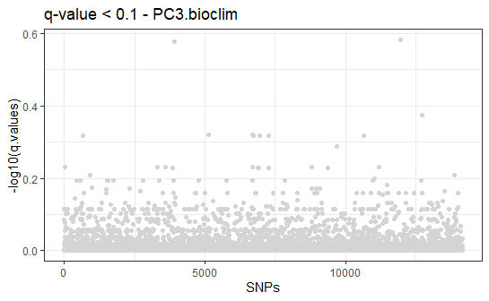

```r
#Third principal component
ggplot() +
  geom_point(aes(x=c(1:length(qvalues_bioclim_pca_Msat$qvalues[,colnames(qvalues_bioclim_pca_Msat$qvalues)[3]])), y=-log10(qvalues_bioclim_pca_Msat$qvalues[,colnames(qvalues_bioclim_pca_Msat$qvalues)[3]])), col = "gray83") +

   geom_point(aes(x=c(1:length(qvalues_bioclim_pca_Msat$qvalues[,colnames(qvalues_bioclim_pca_Msat$qvalues)[3]]))[which(qvalues_bioclim_pca_Msat$qvalues[,colnames(qvalues_bioclim_pca_Msat$qvalues)[3]] < 0.1)], y=-log10(qvalues_bioclim_pca_Msat$qvalues[which(qvalues_bioclim_pca_Msat$qvalues[,colnames(qvalues_bioclim_pca_Msat$qvalues)[3]] < 0.1),1])), col = "blue") +

  xlab("SNPs") + ylab("-log10(q.values)") +
  ggtitle(paste0("q-value < 0.1 - ", colnames(cpvalues_bioclim_pca_Msat)[3])) +
  theme_bw()
```

```r
#Running time ~1s

# Outliers loci (p-value < 0.01)
length(which(cpvalues_bioclim_pca_Msat[,1] < 0.01))
```

```
[1] 220
```

```r
length(which(cpvalues_bioclim_pca_Msat[,2] < 0.01))
```

```
[1] 167
```

```r
length(which(cpvalues_bioclim_pca_Msat[,3] < 0.01))
```

```
[1] 165
```

#RDA-LFMM tables

## All three LFMM-PCA Results table

[output not shown]

[output cut: 14145 more lines]

|  | PC1.bioclim | PC2.bioclim | PC3.bioclim | Principal Component (best association) | Principal Component (p-value) | Principal Component (best significant association) |
| --- | --- | --- | --- | --- | --- | --- |
| S1_46623_A | 0.78008537 | 0.350845249 | 0.73629984 | PC2.bioclim | 0.350845249 | NA |
| S1_102639_A | 0.32140080 | 0.550257796 | 0.58341107 | PC1.bioclim | 0.321400802 | NA |
| S1_102643_C | 0.76529944 | 0.072184326 | 0.25929823 | PC2.bioclim | 0.072184326 | NA |
| S1_176202_C | 0.57679172 | 0.193132825 | 0.81762483 | PC2.bioclim | 0.193132825 | NA |
| S1_193129_A | 0.02772393 | 0.356480940 | 0.94691608 | PC1.bioclim | 0.027723926 | NA |
| S1_201085_A | 0.03821036 | 0.003408271 | 0.01842013 | PC2.bioclim | 0.003408271 | PC2.bioclim |
| S1_202543_T | 0.26131768 | 0.068595725 | 0.00843156 | PC3.bioclim | 0.008431560 | PC3.bioclim |
| S1_202789_T | 0.64294208 | 0.530070454 | 0.28961296 | PC3.bioclim | 0.289612957 | NA |
| S1_222241_A | 0.73526023 | 0.378255299 | 0.09165429 | PC3.bioclim | 0.091654293 | NA |
| S1_222340_A | 0.83894307 | 0.573655493 | 0.07420984 | PC3.bioclim | 0.074209840 | NA |

#cbind RDA-LFMM tables and plots ### M. sativa table

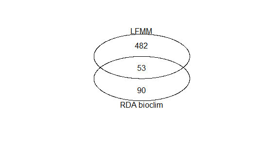

```r
#Running time ~1s

candidates_multi_Msat <- cbind(
  res_rdadapt_bioclim_Msat[2:4],
  candidates_pca_Msativa[4:6])

colnames(candidates_multi_Msat)[1:3] <- c("mahalanobisD RDA bioclim", "p-values RDA bioclim", "q-values RDA bioclim")

candidates_multi_Msat_significant <- candidates_multi_Msat[(candidates_multi_Msat$`p-values RDA bioclim`<=0.01) | candidates_multi_Msat$`Principal Component (p-value)` <=0.01,]

venn(list("RDA bioclim"=rownames(candidates_multi_Msat[(candidates_multi_Msat$`p-values RDA bioclim`<=0.01),]), "LFMM"=rownames(candidates_multi_Msat[(candidates_multi_Msat$`Principal Component (p-value)`<=0.01),])))
```

### M. sativa Manhattan plots

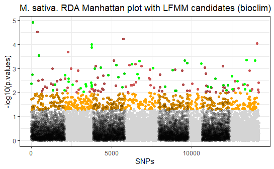

```r
#Running time ~1s

#Joint lists of candidate SNPs
joint_list <- res_rdadapt_bioclim_Msat[which(candidates_multi_Msat$`p-values RDA bioclim`<=0.01 & candidates_multi_Msat$`Principal Component (p-value)`<=0.01, arr.ind = T),1]

ggplot() +
  geom_point(aes(x=c(1:length(res_rdadapt_bioclim_Msat[,3])), y=-log10(res_rdadapt_bioclim_Msat[,3])), col = "gray83") +
  geom_point(aes(x=c(1:length(res_rdadapt_bioclim_Msat[,3]))[which(res_rdadapt_bioclim_Msat[,3] < 0.05)], y=-log10(res_rdadapt_bioclim_Msat[which(res_rdadapt_bioclim_Msat[,3] < 0.05),3])), col = "orange") +
  geom_point(aes(x=c(1:length(res_rdadapt_bioclim_Msat[,3]))[which(res_rdadapt_bioclim_Msat[,3] < 0.01)], y=-log10(res_rdadapt_bioclim_Msat[which(res_rdadapt_bioclim_Msat[,3] < 0.01),3])), col = "indianred3") +

    geom_point(aes(x=c(1:length(res_rdadapt_bioclim_Msat[,3]))[which(res_rdadapt_bioclim_Msat[,1] %in% joint_list)], y=-log10(res_rdadapt_bioclim_Msat[which(res_rdadapt_bioclim_Msat[,1] %in% joint_list),3])), col = "green") +


  geom_point(aes(x= as.integer(rownames(subset(res_rdadapt_bioclim_Msat, grepl("S1", loci) | grepl("S3", loci) | grepl("S5", loci) | grepl("S7", loci)))), y=-log10(subset(res_rdadapt_bioclim_Msat, grepl("S1", loci) | grepl("S3", loci) | grepl("S5", loci) | grepl("S7", loci))[,3])), alpha = .1) +

  xlab("SNPs") + ylab("-log10(p.values)") +
  ggtitle("M. sativa. RDA Manhattan plot with LFMM candidates (bioclim)") +
  theme_bw()
```

```r
joint_list
```

```
 [1] "S1_349977_T"   "S1_1724902_C"  "S1_2108750_C"
 [4] "S1_12573145_A" "S1_35471288_G" "S1_38611325_T"
 [7] "S2_683794_A"   "S2_956456_A"   "S2_6775147_C"
[10] "S2_6995731_C"  "S2_13257021_A" "S2_25066942_T"
[13] "S2_29475047_T" "S2_33643348_A" "S2_34554864_A"
[16] "S2_43040782_C" "S2_43270189_A" "S2_43375349_A"
[19] "S2_43504604_G" "S2_43561715_C" "S3_2574869_C"
[22] "S3_14613171_A" "S3_29037749_T" "S3_40767884_A"
[25] "S3_43696883_G" "S3_51289295_G" "S3_55108765_T"
[28] "S4_15328256_G" "S4_23497849_C" "S4_25739265_A"
[31] "S4_26367559_C" "S4_45191134_T" "S5_9058899_T"
[34] "S5_18544656_C" "S5_22395041_C" "S5_24866305_G"
[37] "S5_39112524_A" "S5_41975953_A" "S6_33589377_G"
[40] "S7_10928549_G" "S7_19833067_G" "S7_27157967_A"
[43] "S7_36829720_G" "S7_41770682_G" "S7_46311124_T"
[46] "S8_5123733_G"  "S8_6454160_T"  "S8_12131363_A"
[49] "S8_26134138_C" "S8_26728360_G" "S8_28405766_A"
[52] "S8_31816501_C" "S8_37647200_A"
```

#Candidates in MedicMine format

```r
candMsat_MedicMine <- gsub("S", "chr", joint_list, fixed =T)
candMsat_MedicMine <- gsub("\\_[A-Z]", "", candMsat_MedicMine)
candMsat_MedicMine <- gsub("_", ":", candMsat_MedicMine)

fileConn<-file("data/candMsat_MedicMine.txt")
writeLines(candMsat_MedicMine, fileConn)
close(fileConn)
```

#Obtain genes in http://medicmine.jcvi.org/medicmine/genomicRegionSearch.do or https://phytozome-next.jgi.doe.gov/phytomine/genomicRegionSearch.do

```r
Msat_GeneIDs <- read.csv("data/results-table.csv")[,1] #results-table.csv
write.csv2(Msat_GeneIDs, file = "data/results-geneIDs-table.csv", row.names = F)
```

#Obtain functional annotation in https://phytozome-next.jgi.doe.gov/phytomine/begin.do - Analyze